# A) By Number of events by manufacturer

- By number of manufacturers and their crash events

```
## # A tibble: 10 x 2
##    devicemanufacturer     n
##    <chr>              <int>
##  1 samsung             4258
##  2 HUAWEI              2572
##  3 Xiaomi               785
##  4 LGE                  538
##  5 asus                 473
##  6 WIKO                 315
##  7 Meizu                144
##  8 Vodafone             127
##  9 motorola             109
## 10 OPPO                 106
```

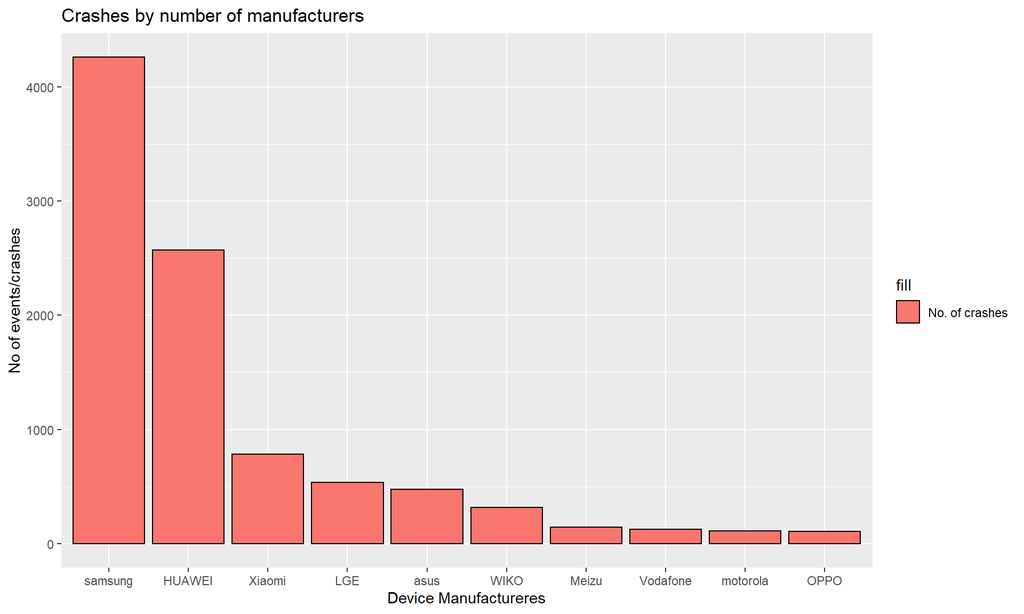

# B) By OS_Versions

- Grouped by the operating systems (OS) version.

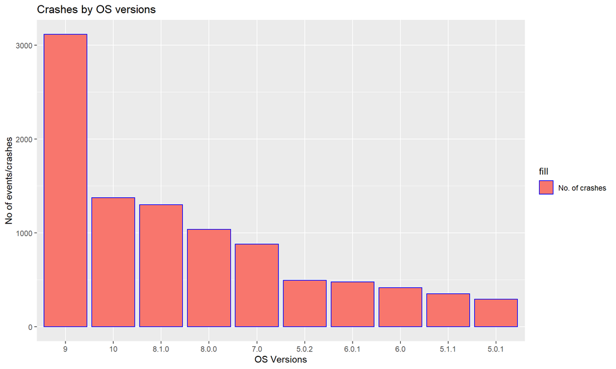

# C) By Device manufacturers and OS Versions

- Samsung with OS 9 and OS 10 have the highest crashes in May.

```
##
##
## | devicemanufacturer | os_version |  n   |
## |:------------------:|:----------:|:----:|
## |      samsung       |     9      | 1301 |
## |      samsung       |     10     | 838  |
## |       HUAWEI       |     9      | 601  |
## |       Xiaomi       |     9      | 533  |
## |      samsung       |   8.0.0    | 461  |
## |      samsung       |   8.1.0    | 445  |
## |      samsung       |    7.0     | 443  |
## |       HUAWEI       |   8.0.0    | 438  |
## |       HUAWEI       |     10     | 338  |
## |       HUAWEI       |    6.0     | 270  |
##
## Table: Events by OS_Versions.
```

# D) By Java class problems

```
##
##
## | &nbsp; |          javaclass          |  n  |
## |:------:|:---------------------------:|:---:|
## | **2**  | ConfirmPushNavFragment.java | 203 |
## | **3**  |  RealInterceptorChain.java  | 132 |
## | **4**  |  PublicSuffixDatabase.java  | 104 |
## | **5**  |         Cookie.java         | 78  |
## | **6**  |        RealCall.java        | 52  |
##
## Table: Events by Java class problems.
```

- ignore the first column

# E) By frame file problems

- Frame file problems, top five are selected.

```
##
##
## |         frame_file          |  n   |
## |:---------------------------:|:----:|
## |  LoginContentProvider.java  | 1391 |
## | ConfirmPushNavFragment.java | 1058 |
## |         Parcel.java         | 901  |
## |        PfmData.java         | 807  |
## |  PublicSuffixDatabase.java  | 705  |
##
## Table: Events by frame file class problems.
```

# F) By Exception messages

- Exception message problems, top five are selected based on the events.

```
## [1] "android.widget.RelativeLayout cannot be cast to android.support.constraint.ConstraintLayout"
## [2] "Before use the engine you must call PaymentsEngine.init(...)"
## [3] "No direct method <init>(Lorg/joda/time/Chronology;Ljava/lang/Object;I)V in class Lorg/joda/time/chrono/BasicChronology; or its super classes (declaration of 'org.joda.time.chrono.BasicChronology' appears in base.apk!classes3.dex)"
## [4] "posteitaliane.posteapp.appbpol.model.Strumento cannot be cast to posteitaliane.posteapp.appbpol.model.ws.ricariche.girofondo.Libretto"
## [5] "Attempt to invoke virtual method 'java.lang.String android.content.Context.getPackageName()' on a null object reference"
```

```
##
##
##  Nomenclature   Events
## -------------- --------
##      [1]         497
##      [2]         203
##      [3]          54
##      [4]          25
##      [5]          16
##
## Table: Events by exception message problems.
```

# G) Overall Fatality rate

- The table indicates that all the crashes were “fatal”.

```
##
##
## | Company  | Crashes | Is_fatal | Not_Fatal |
## |:--------:|:-------:|:--------:|:---------:|
## | samsung  |  4258   |   4258   |     0     |
## |  HUAWEI  |  2572   |   2572   |     0     |
## |  Xiaomi  |   785   |   785    |     0     |
## |   LGE    |   538   |   538    |     0     |
## |   asus   |   473   |   473    |     0     |
## |   WIKO   |   315   |   315    |     0     |
## |  Meizu   |   144   |   144    |     0     |
## | Vodafone |   127   |   127    |     0     |
## | motorola |   109   |   109    |     0     |
##
## Table: Overall fatality descriptives.
```

# H) Device statistics

- Percentage of MEMORY and STORAGE usage during the crash.

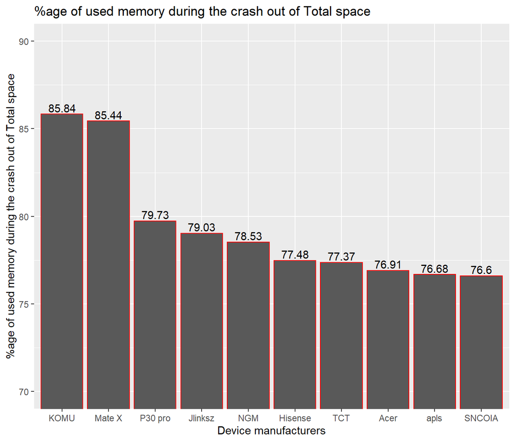

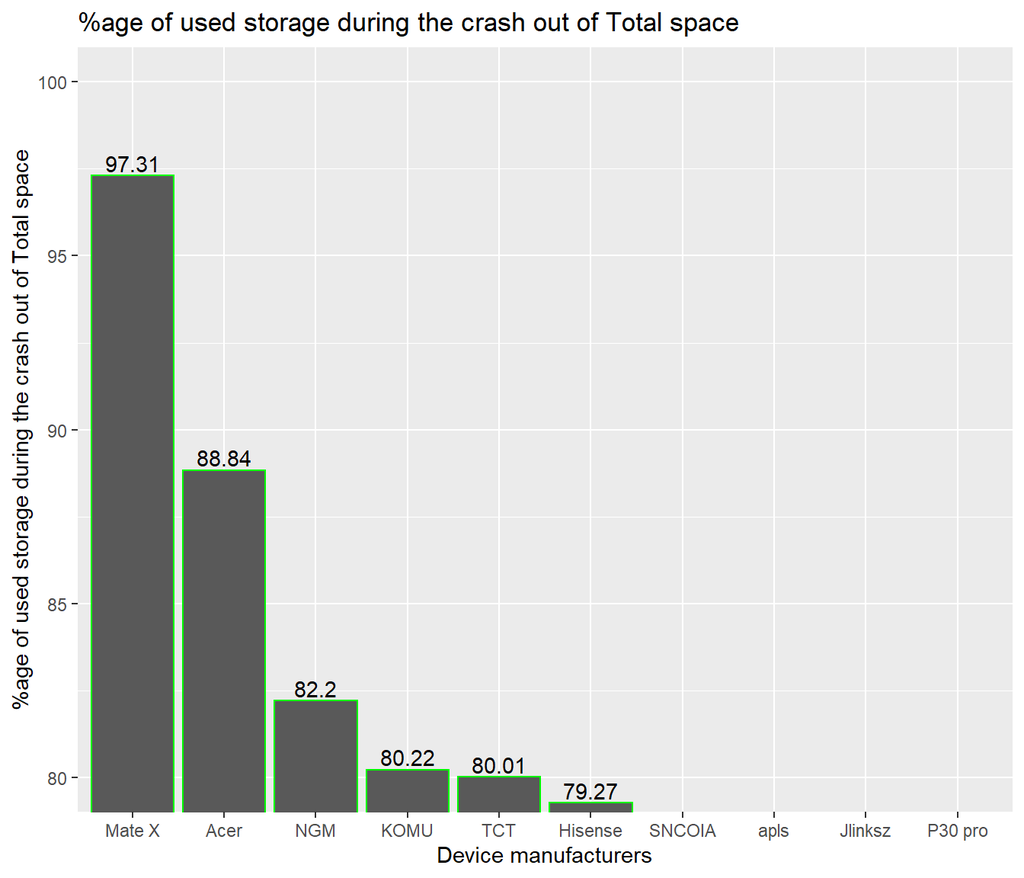

# 1) Analysis for Samsung

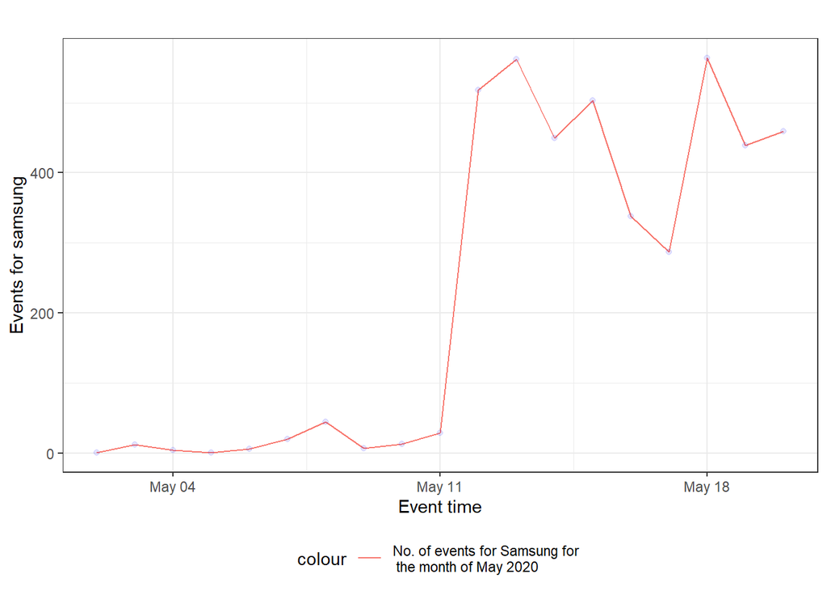

## 1.1) Correlation Coefficient for samsung and important variables

### 1.1.1) Correlation between Samsung and Java class problems

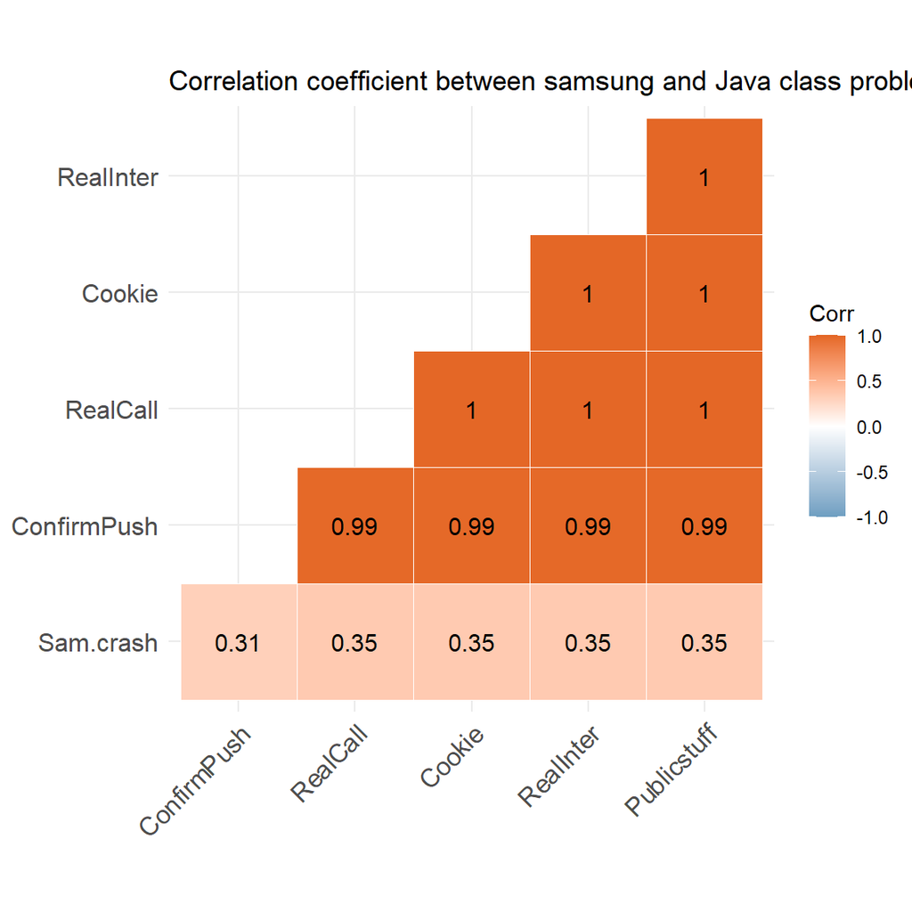

* Sam.crash : Events for samsung * ConfirmPush, RealCall, Cookie and Realinter are java class problems that brought the event.

### 1.1.2) Correlation between Samsung and Memory usage over time

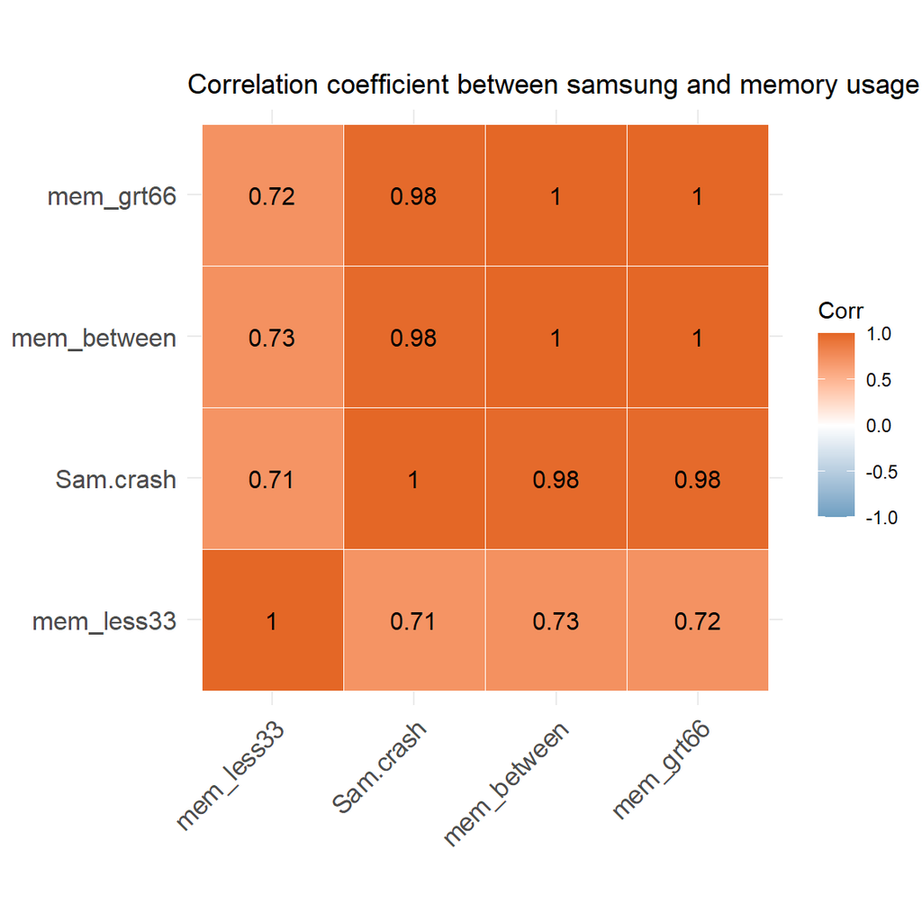

- Sam.crash : Events for samsung
- mem_less33 : 33% and less of Memory usage during the event
- mem_between : 34% - 65% of Memory usage during the event
- mem_grt66 : 66% and higher of Memory usage during the event

### 1.1.3) Correlation between Samsung and Storage usage over time

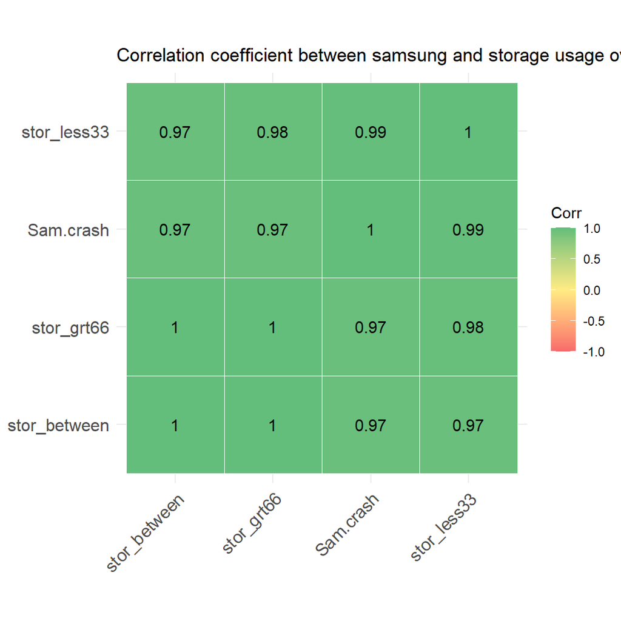

- Sam.crash : Events for samsung
- stor_less33 : 33% and less of Story usage during the event
- stor_between : 34% - 65% of Story usage during the event
- stor_grt66 : 66% and higher of Story usage during the event

### 1.1.4) Correlation between Samsung and frame_file

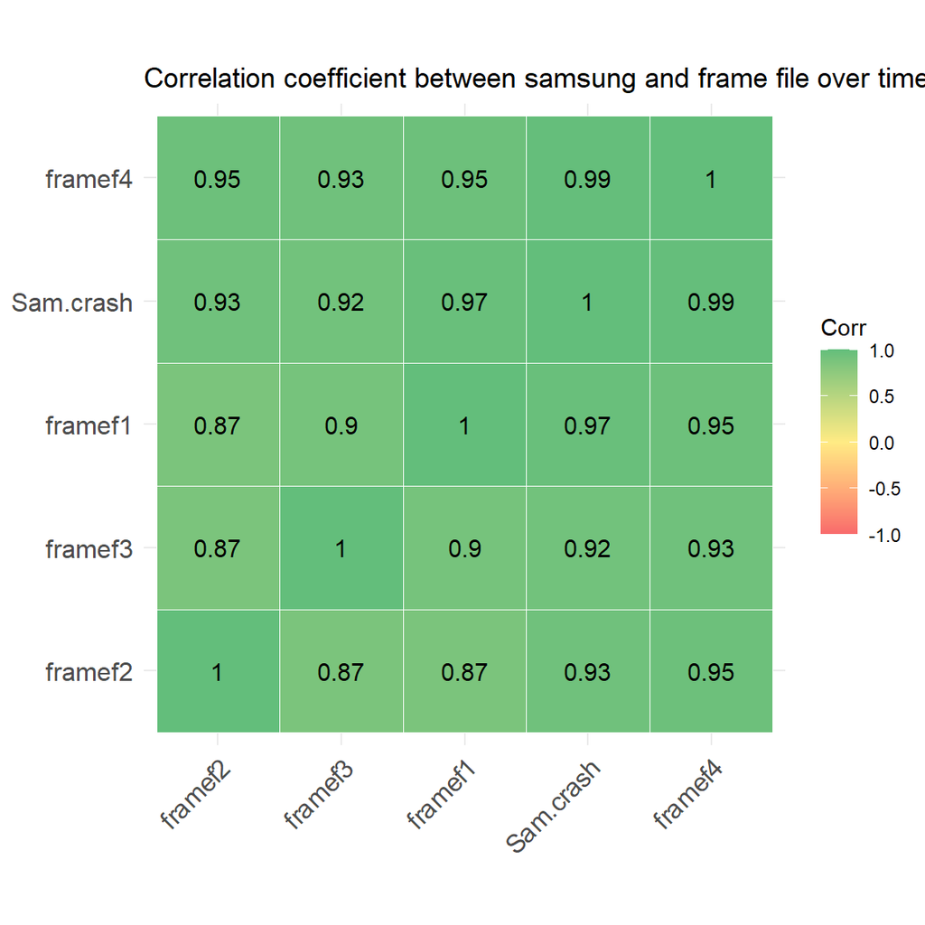

* Sam.crash : Events for samsung * frame1 : LoginContentProvider.java * frame2 : ConfirmPushNavFragment.java * frame3 : Parcel.java * frame4 : PfmData.java * frame1-4 : they are top four frame_file problems that contributed for the events.

# 2) Analysis for HUAWEI

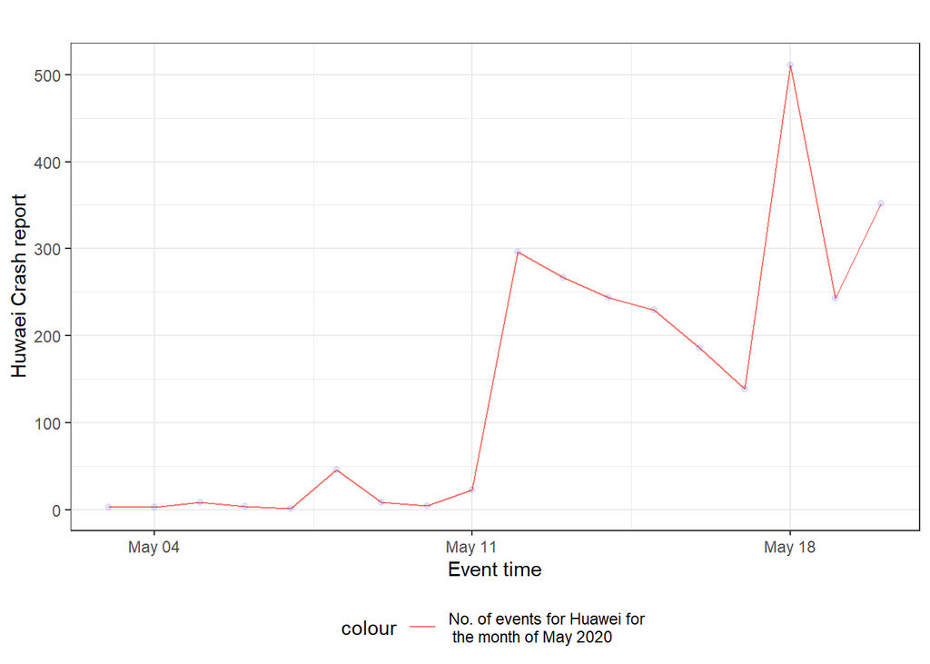

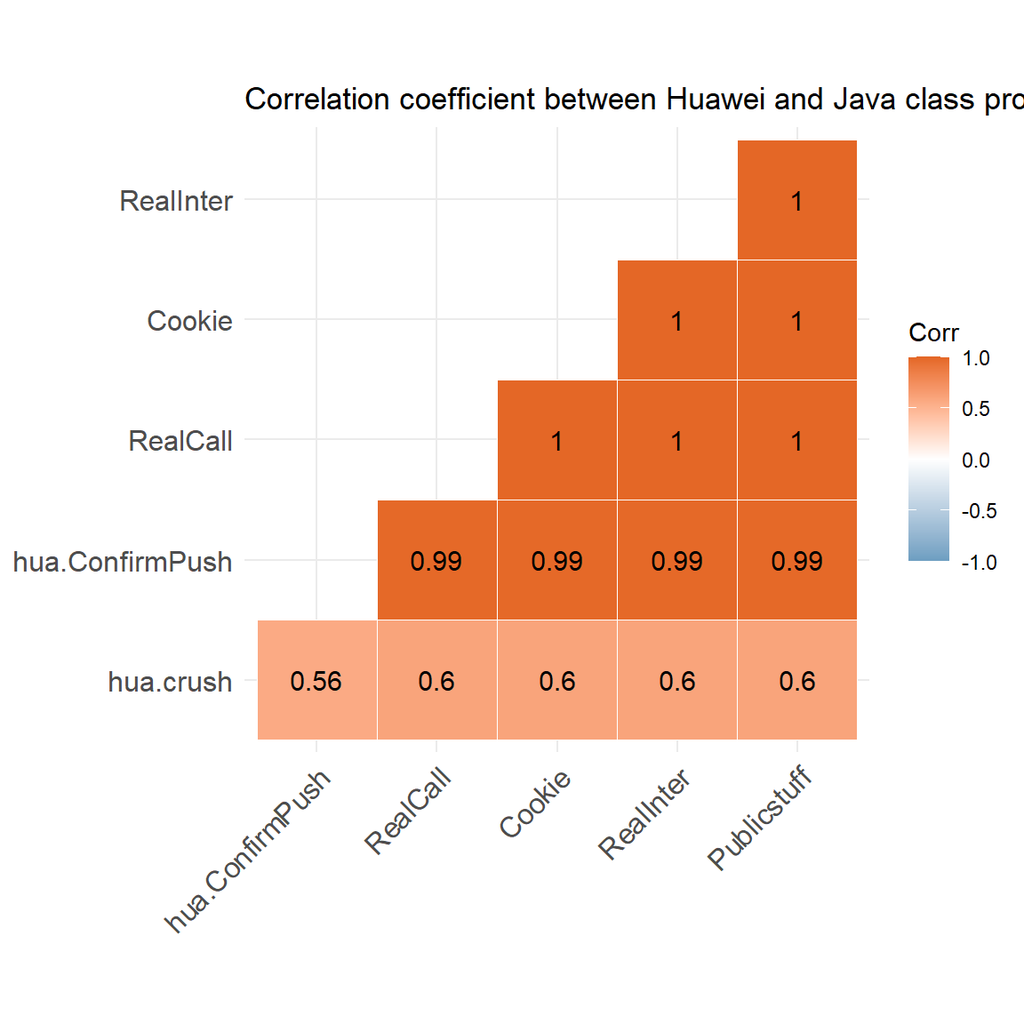

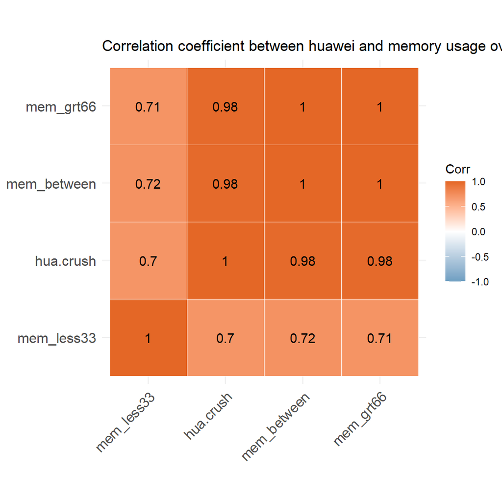

[figure not shown]

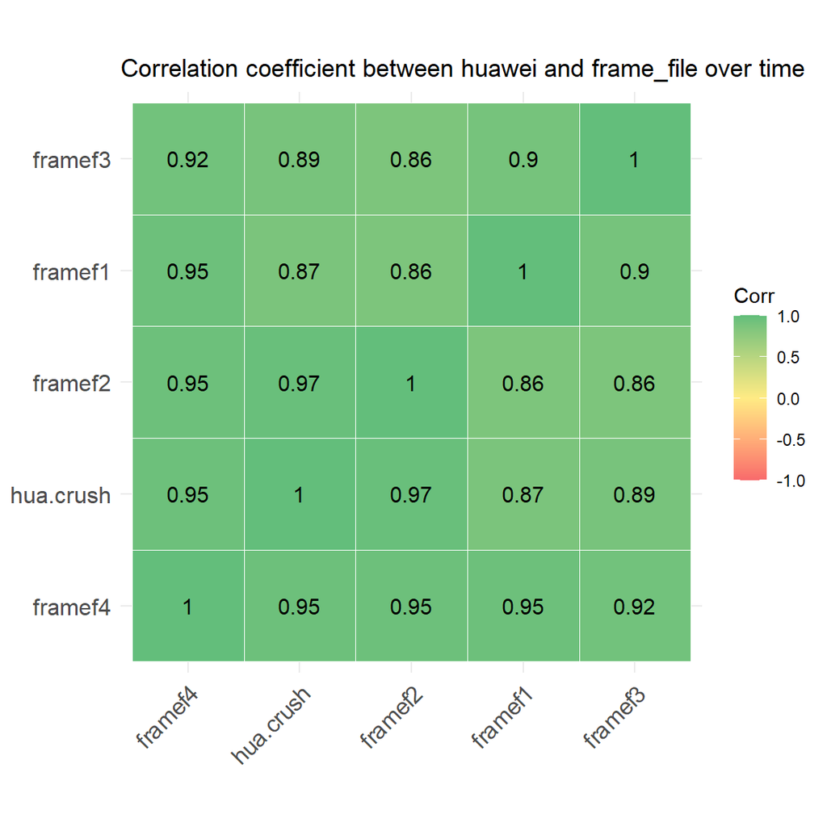

* Hua.crash : Events for Huawei * ConfirmPush, RealCall, Cookie and Realinter are java class problems that brought the event. * mem_less33 : 33% and less of Memory usage during the event * mem_between : 34% - 65% of Memory usage during the event * mem_grt66 : 66% and higher of Memory usage during the event * stor_less33 : 33% and less of Story usage during the event * stor_between : 34% - 65% of Story usage during the event * stor_grt66 : 66% and higher of Story usage during the event * frame1 : LoginContentProvider.java & is frame file problem * frame2 : ConfirmPushNavFragment.java & is frame file problem * frame3 : Parcel.java & is frame file problem * frame4 : PfmData.java & is frame file problem

# 3) Analysis for XIAOMI

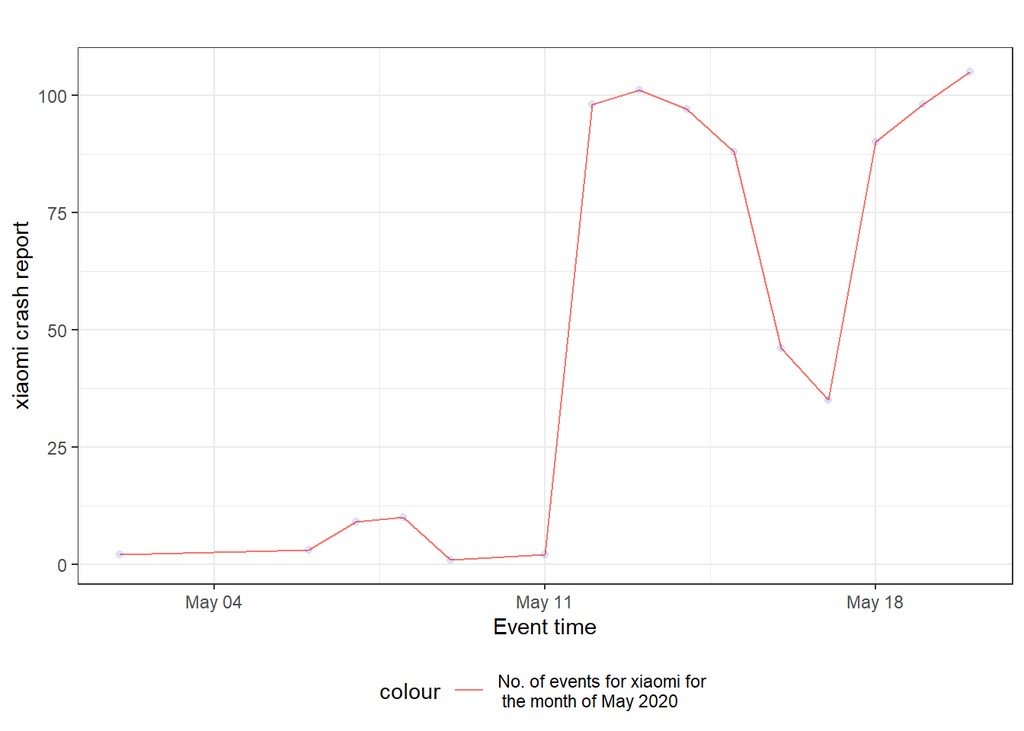

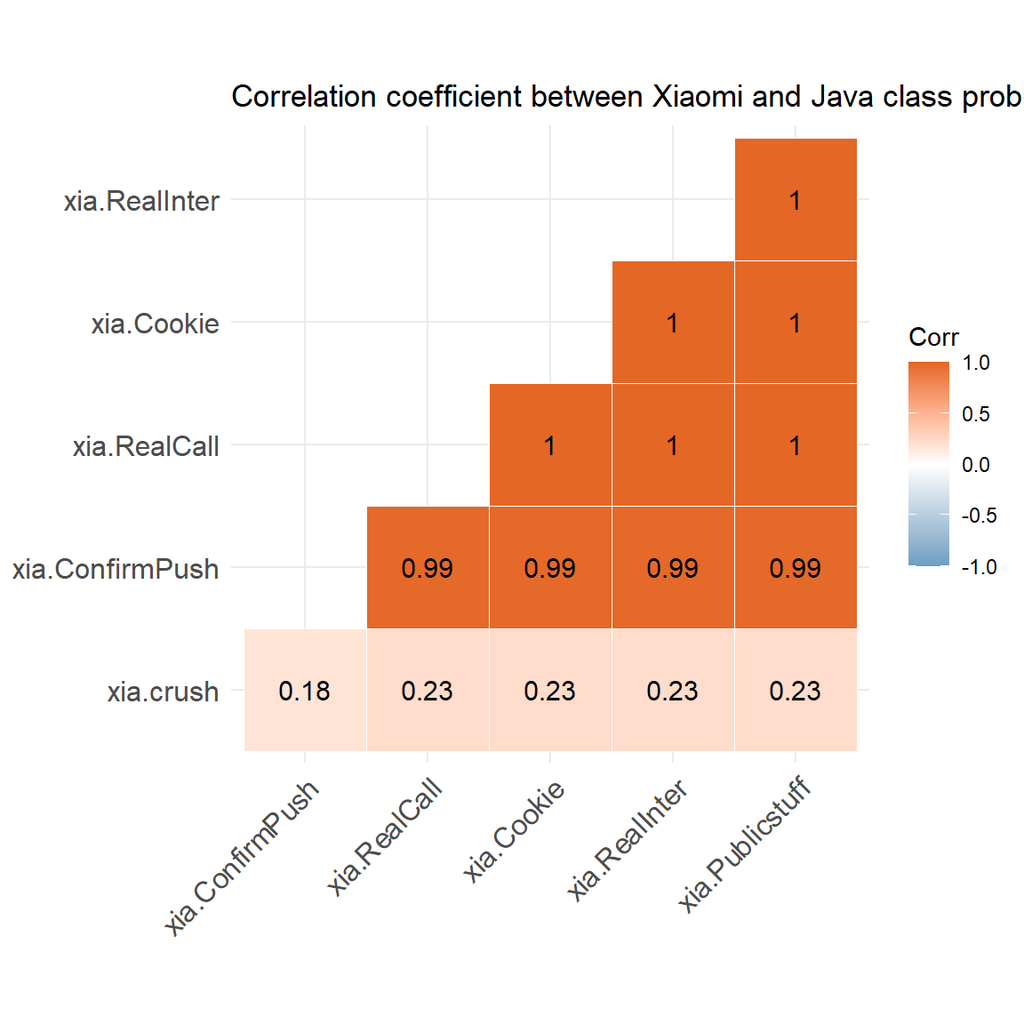

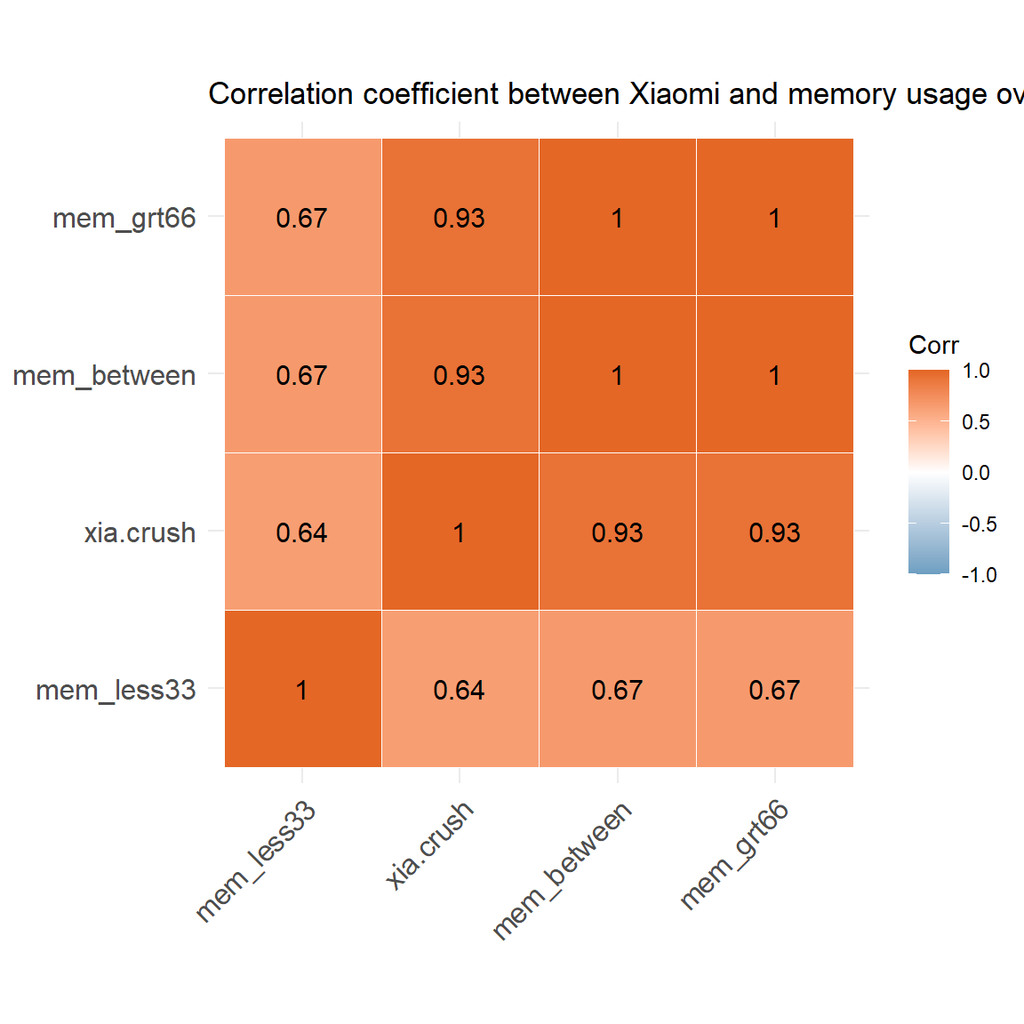

[figure not shown]

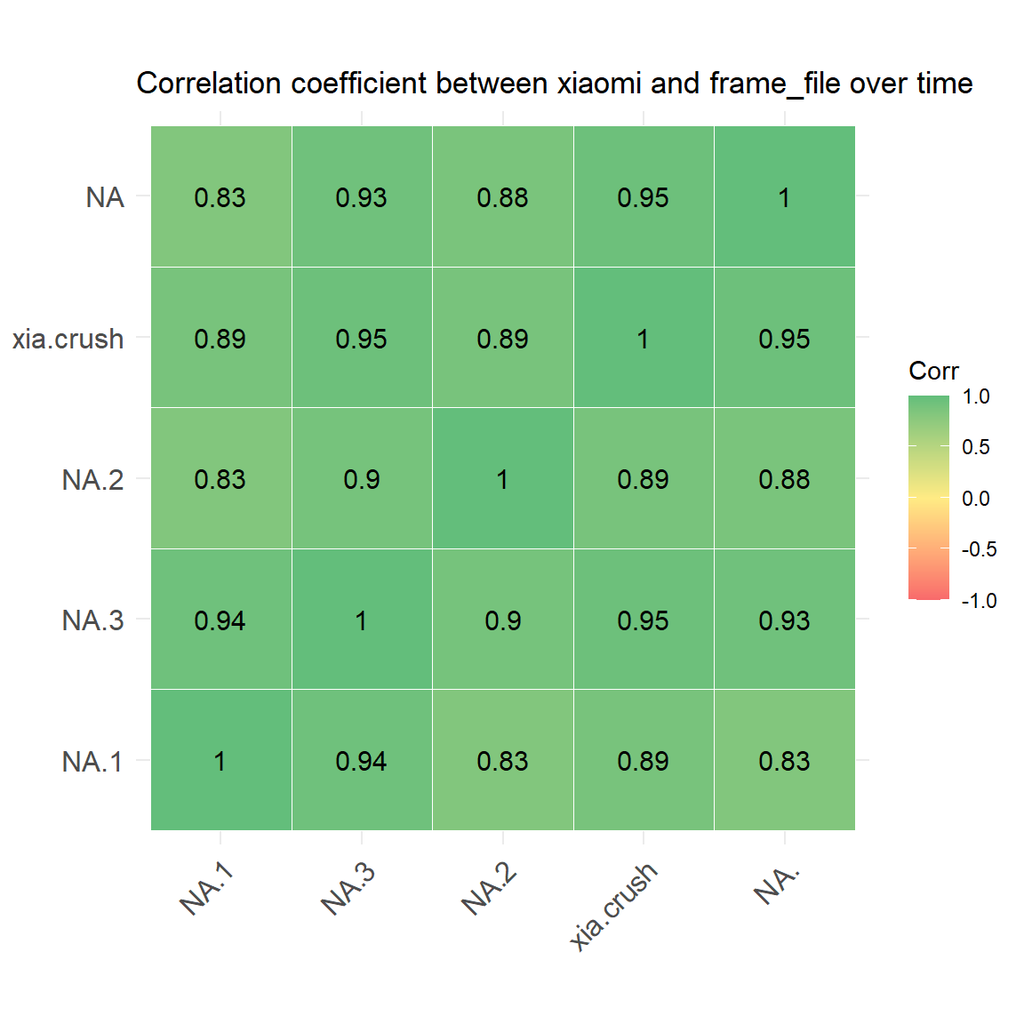

- xia.crash : Events for Xiaomi
- ConfirmPush, RealCall, Cookie and Realinter are java class problems that brought the event.
- mem_less33 : 33% and less of Memory usage during the event
- mem_between : 34% - 65% of Memory usage during the event
- mem_grt66 : 66% and higher of Memory usage during the event
- stor_less33 : 33% and less of Story usage during the event
- stor_between : 34% - 65% of Story usage during the event
- stor_grt66 : 66% and higher of Story usage during the event
- frame1 : LoginContentProvider.java & is frame file problem
- frame2 : ConfirmPushNavFragment.java & is frame file problem
- frame3 : Parcel.java & is frame file problem
- frame4 : PfmData.java & is frame file problem

# 4) Analysis for LGE

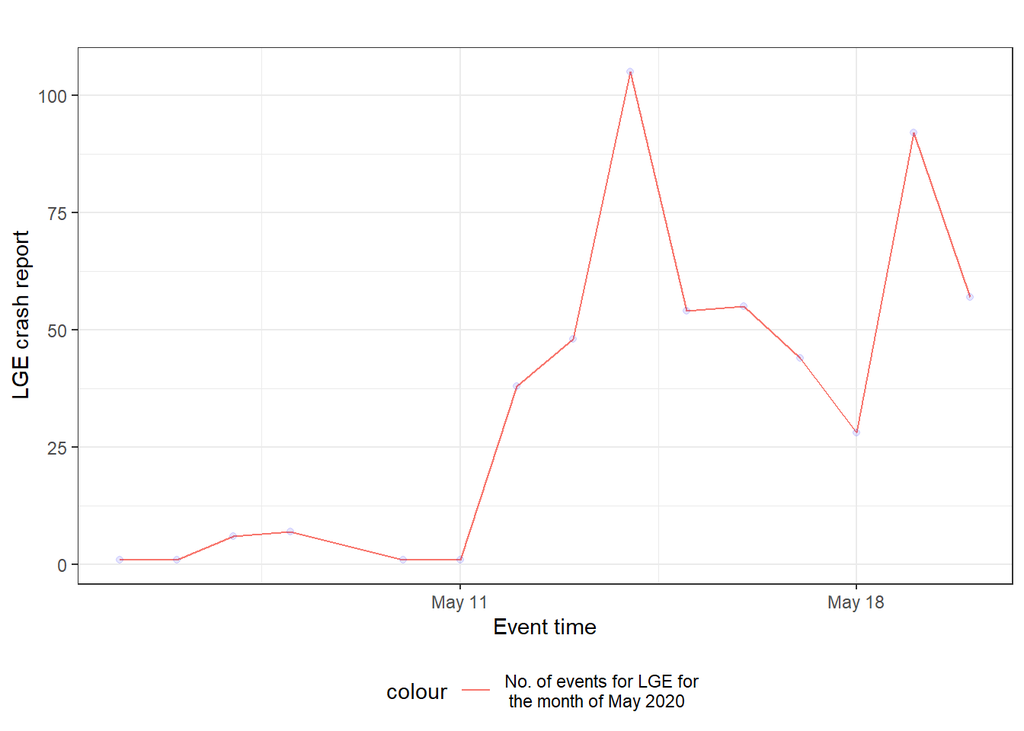

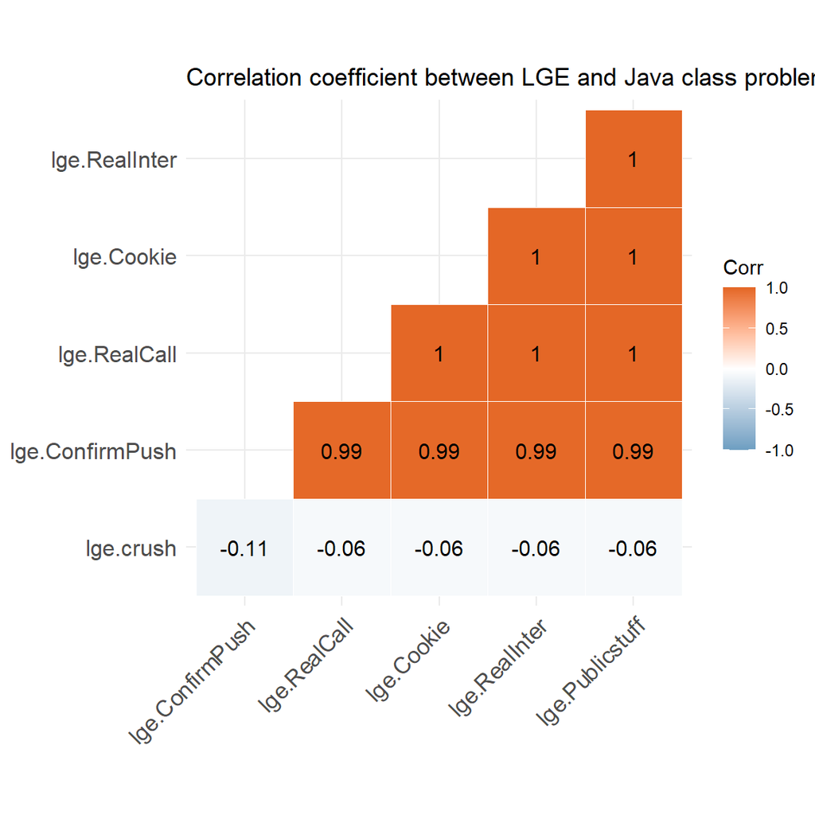

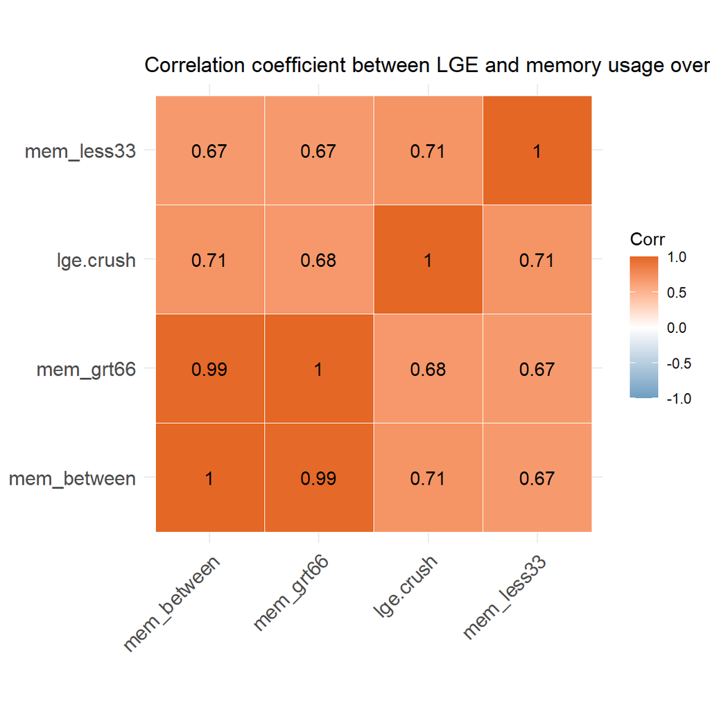

[figure not shown]

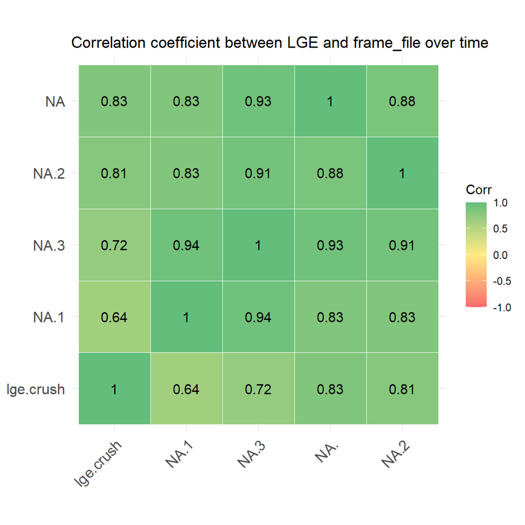

- lge.crash : Events for LGE
- ConfirmPush, RealCall, Cookie and Realinter are java class problems that brought the event.
- mem_less33 : 33% and less of Memory usage during the event
- mem_between : 34% - 65% of Memory usage during the event
- mem_grt66 : 66% and higher of Memory usage during the event
- stor_less33 : 33% and less of Story usage during the event
- stor_between : 34% - 65% of Story usage during the event
- stor_grt66 : 66% and higher of Story usage during the event
- frame1 : LoginContentProvider.java & is frame file problem
- frame2 : ConfirmPushNavFragment.java & is frame file problem
- frame3 : Parcel.java & is frame file problem
- frame4 : PfmData.java & is frame file problem

# 5) Analysis for ASUS

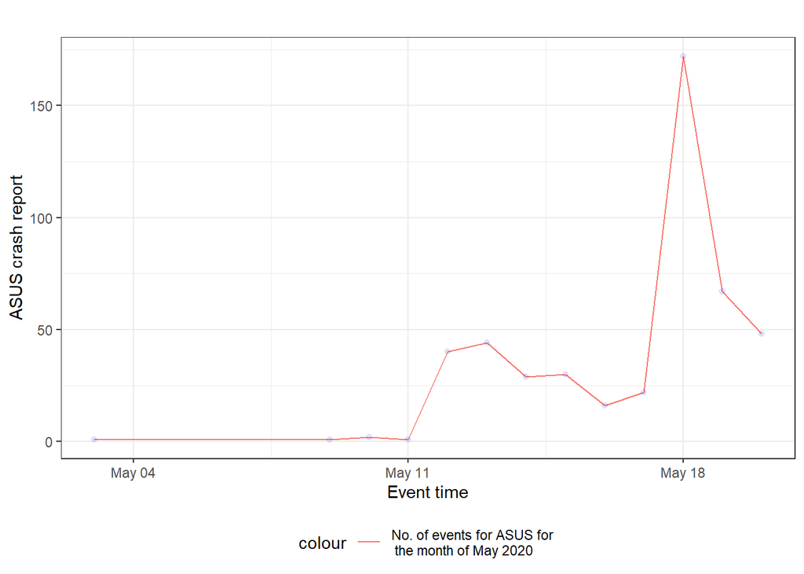

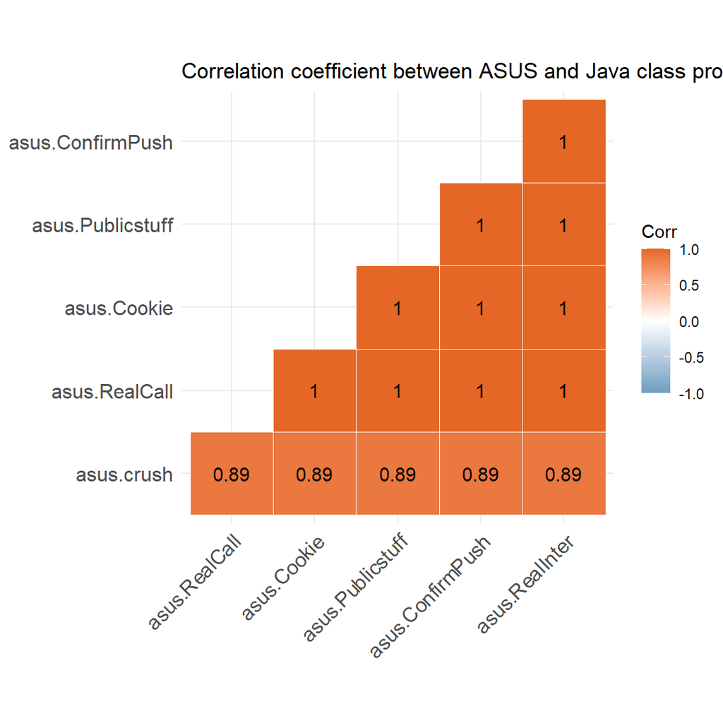

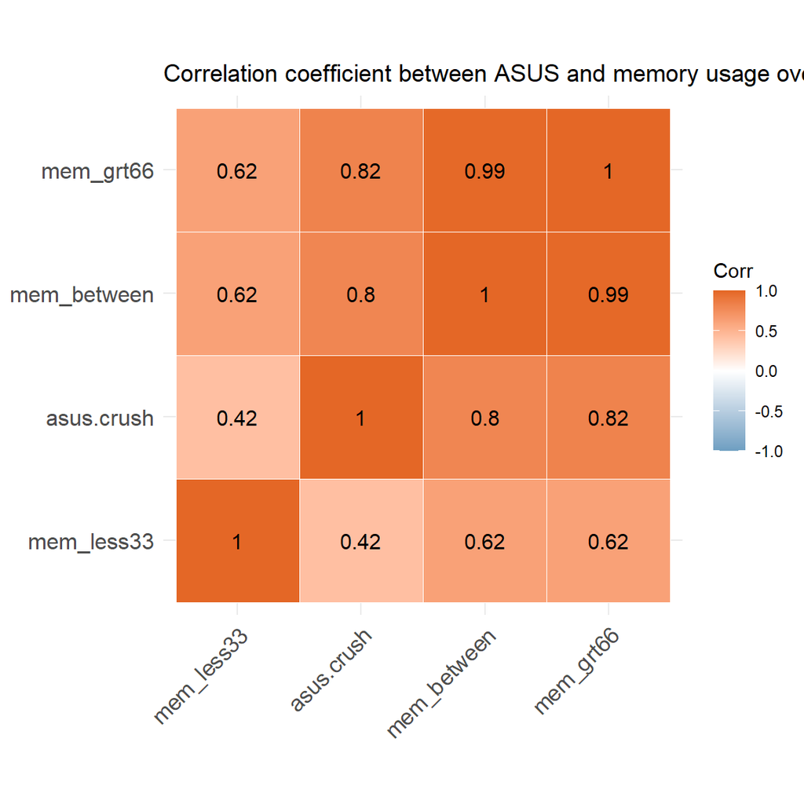

[figure not shown]

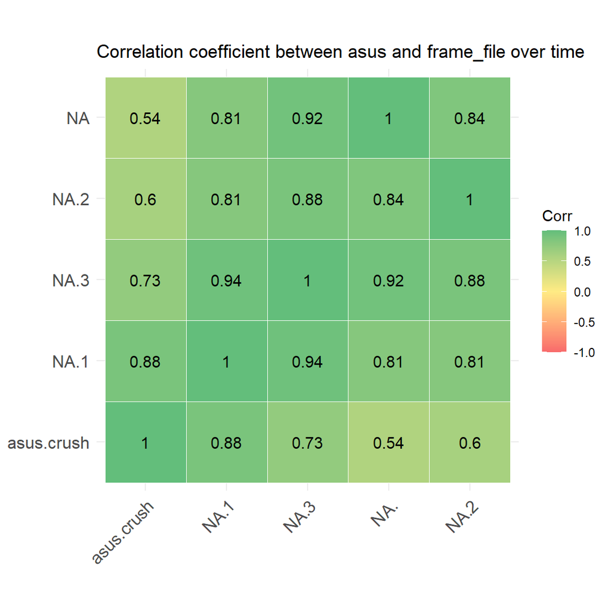

- asus.crash : Events for ASUS
- ConfirmPush, RealCall, Cookie and Realinter are java class problems that brought the event.
- mem_less33 : 33% and less of Memory usage during the event
- mem_between : 34% - 65% of Memory usage during the event
- mem_grt66 : 66% and higher of Memory usage during the event
- stor_less33 : 33% and less of Story usage during the event
- stor_between : 34% - 65% of Story usage during the event
- stor_grt66 : 66% and higher of Story usage during the event
- frame1 : LoginContentProvider.java & is frame file problem
- frame2 : ConfirmPushNavFragment.java & is frame file problem
- frame3 : Parcel.java & is frame file problem
- frame4 : PfmData.java & is frame file problem

# 6) Analysis for WIKO

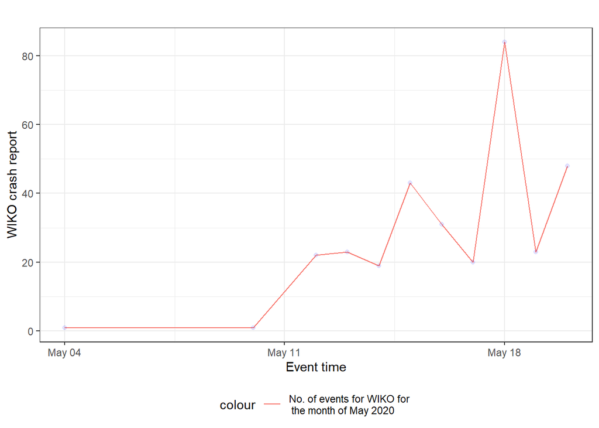

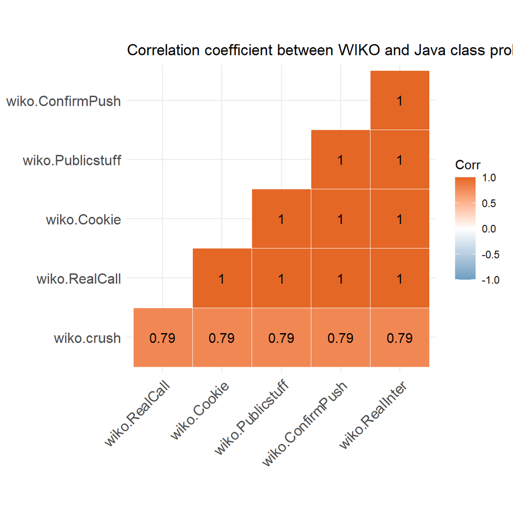

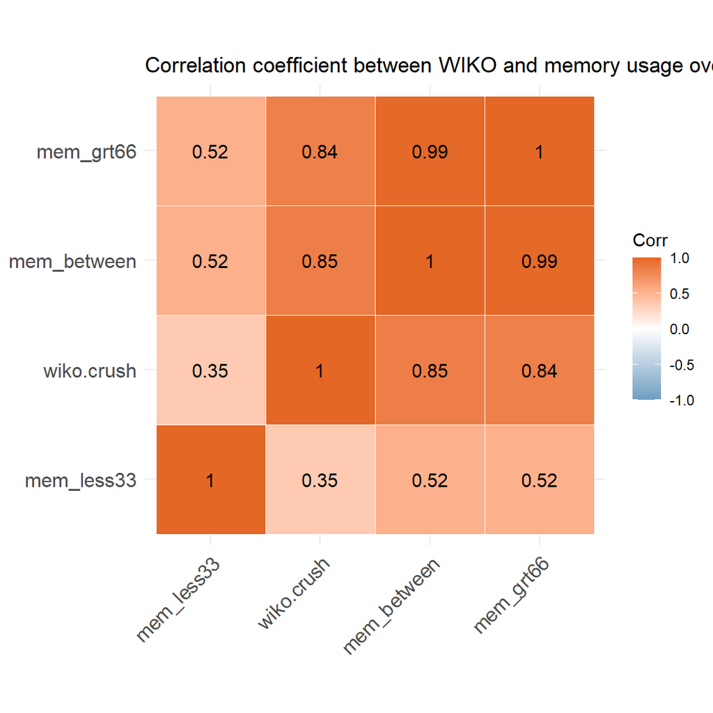